# Predicting Terrorism

```python
import pandas as pd
import glob
import pandas as pd
import numpy as np

db = '/Users/jennydoyle/Desktop/dsi/04-project-assets/globalterrorismdb_0616dist.csv'
df = pd.read_csv(db, header=0,low_memory=False)
print 'Size = ', df.shape
```

```
Size =  (156772, 137)
```

# I. EDA

```python
def eda(dataframe):
    from IPython.core import display as ICD
    print "dataframe shape: ",dataframe.shape      ## rows by columns
    print ''
    print 'num duplicates:', dataframe.duplicated().sum() ## df.drop_duplicates() to remove dupes
    print ''
    print "pct missing values \n"
    ICD.display(pd.DataFrame(dataframe.isnull().sum()/len(df)*100),columns=['Columns','Pct Missing']), ## count number of null values per column
    print ''
    print "dataframe types \n"
    ICD.display(pd.DataFrame(dataframe.dtypes),columns=['Columns','Dtype'])       ## list data type of each column
    print ''
    print "dataframe describe \n"
    ICD.display(pd.DataFrame(dataframe.describe()))## stats -- mean, min, max, etc..
    print ''
    print '# unique values in series:\n'
    u_list = []
    for item in dataframe:                             ## count number of unique values per column
        u_list.append([item, dataframe[item].nunique()])
    unique_vals = pd.DataFrame(u_list,columns=['Column','Num_unique'])
    ICD.display(unique_vals)

eda(df)
```

```
dataframe shape:  (156772, 137)

num duplicates: 0

pct missing values
```

|  | 0 |
| --- | --- |
| eventid | 0.000000 |
| iyear | 0.000000 |
| imonth | 0.000000 |
| iday | 0.000000 |
| approxdate | 96.966295 |
| extended | 0.000000 |
| resolution | 97.766183 |
| country | 0.000000 |
| country_txt | 0.000000 |
| region | 0.000000 |
| region_txt | 0.000000 |
| provstate | 9.261858 |
| city | 0.284490 |
| latitude | 2.882530 |
| longitude | 2.882530 |
| specificity | 0.000000 |
| vicinity | 0.000000 |
| location | 73.074911 |
| summary | 42.188656 |
| crit1 | 0.000000 |
| crit2 | 0.000000 |
| crit3 | 0.000000 |
| doubtterr | 0.000638 |
| alternative | 84.540607 |
| alternative_txt | 0.000000 |
| multiple | 0.000000 |
| success | 0.000000 |
| suicide | 0.000000 |
| attacktype1 | 0.000000 |
| attacktype1_txt | 0.000000 |
| ... | ... |
| propextent | 64.054806 |
| propextent_txt | 0.000000 |
| propvalue | 80.027046 |
| propcomment | 68.475238 |
| ishostkid | 0.113541 |
| nhostkid | 92.812492 |
| nhostkidus | 92.847575 |
| nhours | 97.893757 |
| ndays | 95.801546 |
| divert | 99.815656 |
| kidhijcountry | 97.901411 |
| ransom | 52.101141 |
| ransomamt | 99.237747 |
| ransomamtus | 99.737836 |
| ransompaid | 99.602608 |
| ransompaidus | 99.743577 |
| ransomnote | 99.731457 |
| hostkidoutcome | 94.460108 |
| hostkidoutcome_txt | 0.000000 |
| nreleased | 94.836450 |
| addnotes | 86.015360 |
| scite1 | 42.309851 |
| scite2 | 60.987294 |
| scite3 | 78.228255 |
| dbsource | 0.000000 |
| INT_LOG | 0.000000 |
| INT_IDEO | 0.000000 |
| INT_MISC | 0.000000 |
| INT_ANY | 0.000000 |
| related | 86.973439 |

137 rows × 1 columns

```
dataframe types
```

|  | 0 |
| --- | --- |
| eventid | int64 |
| iyear | int64 |
| imonth | int64 |
| iday | int64 |
| approxdate | object |
| extended | int64 |
| resolution | object |
| country | int64 |
| country_txt | object |
| region | int64 |
| region_txt | object |
| provstate | object |
| city | object |
| latitude | float64 |
| longitude | float64 |
| specificity | int64 |
| vicinity | int64 |
| location | object |
| summary | object |
| crit1 | int64 |
| crit2 | int64 |
| crit3 | int64 |
| doubtterr | float64 |
| alternative | float64 |
| alternative_txt | object |
| multiple | int64 |
| success | int64 |
| suicide | int64 |
| attacktype1 | int64 |
| attacktype1_txt | object |
| ... | ... |
| propextent | float64 |
| propextent_txt | object |
| propvalue | float64 |
| propcomment | object |
| ishostkid | float64 |
| nhostkid | float64 |
| nhostkidus | float64 |
| nhours | float64 |
| ndays | float64 |
| divert | object |
| kidhijcountry | object |
| ransom | float64 |
| ransomamt | float64 |
| ransomamtus | float64 |
| ransompaid | float64 |
| ransompaidus | float64 |
| ransomnote | object |
| hostkidoutcome | float64 |
| hostkidoutcome_txt | object |
| nreleased | float64 |
| addnotes | object |
| scite1 | object |
| scite2 | object |
| scite3 | object |
| dbsource | object |
| INT_LOG | int64 |
| INT_IDEO | int64 |
| INT_MISC | int64 |
| INT_ANY | int64 |
| related | object |

137 rows × 1 columns

```
dataframe describe
```

|  | eventid | iyear | imonth | iday | extended | country | region | latitude | longitude | specificity | ... | ransomamt | ransomamtus | ransompaid | ransompaidus | hostkidoutcome | nreleased | INT_LOG | INT_IDEO | INT_MISC | INT_ANY |
| --- | --- | --- | --- | --- | --- | --- | --- | --- | --- | --- | --- | --- | --- | --- | --- | --- | --- | --- | --- | --- | --- |
| count | 1.567720e+05 | 156772.000000 | 156772.000000 | 156772.000000 | 156772.000000 | 156772.000000 | 156772.000000 | 152253.000000 | 152253.000000 | 156772.000000 | ... | 1.195000e+03 | 4.110000e+02 | 6.230000e+02 | 402.000000 | 8685.000000 | 8095.000000 | 156772.000000 | 156772.000000 | 156772.000000 | 156772.000000 |
| mean | 2.000541e+11 | 2000.474083 | 6.484666 | 15.455215 | 0.041347 | 133.087401 | 6.970097 | 23.190988 | 24.210467 | 1.452632 | ... | 3.320127e+06 | 5.454451e+05 | 4.319721e+05 | 305.196517 | 4.592170 | -27.788635 | -4.834645 | -4.789114 | 0.093894 | -4.221124 |
| std | 1.298283e+09 | 12.982397 | 3.392225 | 8.815533 | 0.199091 | 113.946290 | 2.967803 | 19.220723 | 59.900831 | 1.016971 | ... | 3.187694e+07 | 6.665967e+06 | 2.589893e+06 | 3409.027685 | 2.049184 | 58.524976 | 4.528862 | 4.589779 | 0.602442 | 4.686143 |
| min | 1.970000e+11 | 1970.000000 | 0.000000 | 0.000000 | 0.000000 | 4.000000 | 1.000000 | -53.154613 | -176.176447 | 1.000000 | ... | -9.900000e+01 | -9.900000e+01 | -9.900000e+01 | -99.000000 | 1.000000 | -99.000000 | -9.000000 | -9.000000 | -9.000000 | -9.000000 |
| 25% | 1.989082e+11 | 1989.000000 | 4.000000 | 8.000000 | 0.000000 | 69.000000 | 5.000000 | 10.756961 | -1.929857 | 1.000000 | ... | 0.000000e+00 | 0.000000e+00 | -9.900000e+01 | 0.000000 | 2.000000 | -99.000000 | -9.000000 | -9.000000 | 0.000000 | -9.000000 |
| 50% | 2.005071e+11 | 2005.000000 | 6.000000 | 15.000000 | 0.000000 | 101.000000 | 6.000000 | 31.285506 | 41.919647 | 1.000000 | ... | 1.250000e+04 | 0.000000e+00 | 0.000000e+00 | 0.000000 | 4.000000 | 0.000000 | -9.000000 | -9.000000 | 0.000000 | 0.000000 |
| 75% | 2.013060e+11 | 2013.000000 | 9.000000 | 23.000000 | 0.000000 | 160.000000 | 10.000000 | 34.842222 | 68.416974 | 1.000000 | ... | 4.115000e+05 | 0.000000e+00 | 4.276840e+03 | 0.000000 | 7.000000 | 1.000000 | 0.000000 | 0.000000 | 0.000000 | 0.000000 |
| max | 2.015123e+11 | 2015.000000 | 12.000000 | 31.000000 | 1.000000 | 1004.000000 | 12.000000 | 74.633553 | 179.366667 | 5.000000 | ... | 1.000000e+09 | 1.320000e+08 | 4.100000e+07 | 48000.000000 | 7.000000 | 1201.000000 | 1.000000 | 1.000000 | 1.000000 | 1.000000 |

8 rows × 79 columns

```
# unique values in series:
```

|  | Column | Num_unique |
| --- | --- | --- |
| 0 | eventid | 156772 |
| 1 | iyear | 45 |
| 2 | imonth | 13 |
| 3 | iday | 32 |
| 4 | approxdate | 1426 |
| 5 | extended | 2 |
| 6 | resolution | 2657 |
| 7 | country | 206 |
| 8 | country_txt | 206 |
| 9 | region | 12 |
| 10 | region_txt | 12 |
| 11 | provstate | 2509 |
| 12 | city | 31324 |
| 13 | latitude | 52021 |
| 14 | longitude | 51632 |
| 15 | specificity | 5 |
| 16 | vicinity | 3 |
| 17 | location | 35794 |
| 18 | summary | 34335 |
| 19 | crit1 | 2 |
| 20 | crit2 | 2 |
| 21 | crit3 | 2 |
| 22 | doubtterr | 3 |
| 23 | alternative | 5 |
| 24 | alternative_txt | 6 |
| 25 | multiple | 2 |
| 26 | success | 2 |
| 27 | suicide | 2 |
| 28 | attacktype1 | 9 |
| 29 | attacktype1_txt | 9 |
| ... | ... | ... |
| 107 | propextent | 4 |
| 108 | propextent_txt | 5 |
| 109 | propvalue | 604 |
| 110 | propcomment | 17437 |
| 111 | ishostkid | 3 |
| 112 | nhostkid | 221 |
| 113 | nhostkidus | 28 |
| 114 | nhours | 34 |
| 115 | ndays | 289 |
| 116 | divert | 142 |
| 117 | kidhijcountry | 217 |
| 118 | ransom | 3 |
| 119 | ransomamt | 350 |
| 120 | ransomamtus | 21 |
| 121 | ransompaid | 122 |
| 122 | ransompaidus | 8 |
| 123 | ransomnote | 285 |
| 124 | hostkidoutcome | 7 |
| 125 | hostkidoutcome_txt | 8 |
| 126 | nreleased | 155 |
| 127 | addnotes | 9613 |
| 128 | scite1 | 66698 |
| 129 | scite2 | 50118 |
| 130 | scite3 | 28489 |
| 131 | dbsource | 26 |
| 132 | INT_LOG | 3 |
| 133 | INT_IDEO | 3 |
| 134 | INT_MISC | 3 |
| 135 | INT_ANY | 3 |
| 136 | related | 18082 |

137 rows × 2 columns

#### Define graph settings

```python
%matplotlib inline
import matplotlib.pyplot as plt
plt.rcParams['figure.figsize'] = (10, 8)
plt.rcParams['font.size'] = 30
plt.rcParams['font.family'] = 'Courier New, monospace'
plt.rcParams['xtick.labelsize'] = 20
plt.rcParams['ytick.labelsize'] = 20
```

## Exploring the Data

**GOAL**: Find something interesting to use in a Bayesian Inference

#### Types and Counts of Attack Types

```python
df.attacktype1_txt.value_counts()
```

```
Bombing/Explosion                      75963
Armed Assault                          37554
Assassination                          17582
Hostage Taking (Kidnapping)             9115
Facility/Infrastructure Attack          8849
Unknown                                 5490
Hostage Taking (Barricade Incident)      835
Unarmed Assault                          828
Hijacking                                556
Name: attacktype1_txt, dtype: int64
```

## So Many Graphs

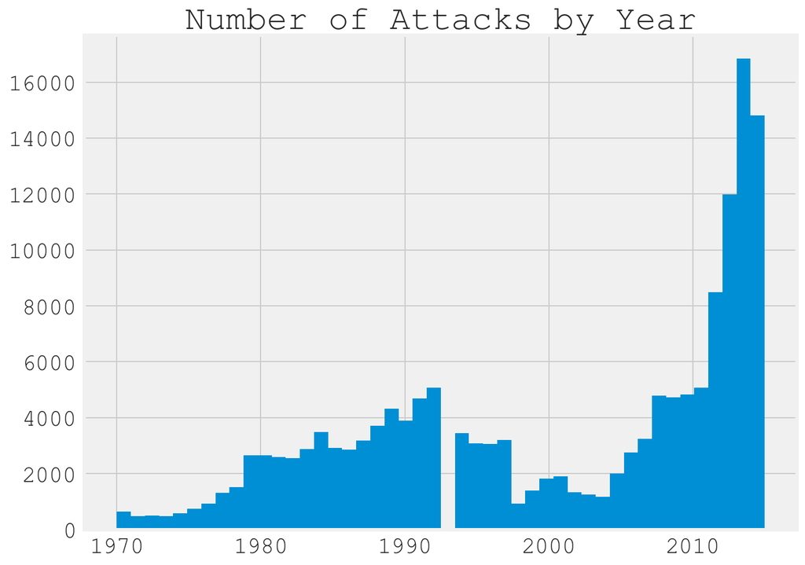

```python
plt.hist(df.iyear,bins=46)
plt.title('Number of Attacks by Year',fontsize=30)
plt.show()
```

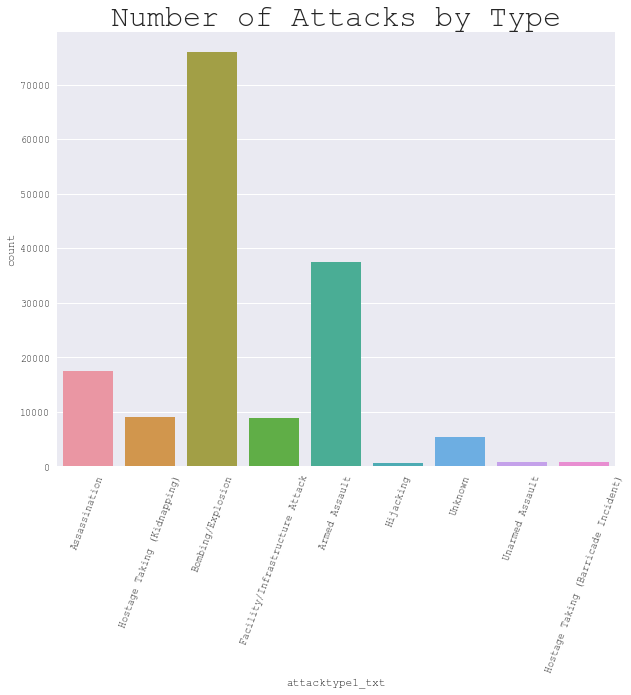

```python
import seaborn as sns
plt.rcParams['figure.figsize'] = (10, 8)
# plt.rcParams['font.size'] = 30
plt.rcParams['font.family'] = 'Courier New, monospace'
plt.rcParams['xtick.labelsize'] = 10
# plt.rcParams['ytick.labelsize'] = 20
sns.countplot(x="attacktype1_txt", data=df)
plt.title('Number of Attacks by Type',size=30)
plt.xticks(rotation=70)
plt.show()
```

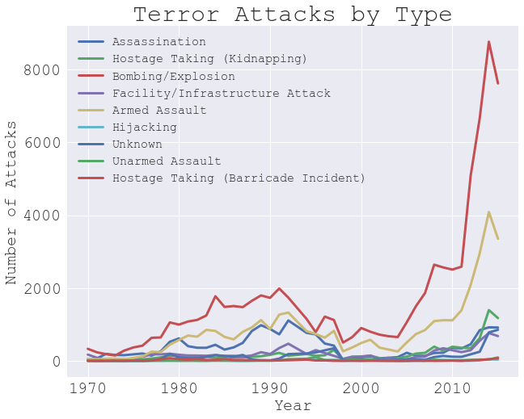

```python
attacks_by_type = df[['iyear','attacktype1_txt','attacktype1']].groupby(['iyear','attacktype1_txt']).attacktype1.count().reset_index()
attacks_by_type.rename(columns={'attacktype1_txt':'Attack Type'},inplace=True)
attacks_by_type.set_index('iyear',inplace=True)

for atype in list(df.attacktype1_txt.unique()):
    plt.plot(attacks_by_type[['attacktype1']][attacks_by_type['Attack Type']==atype],label=atype,linewidth=3.0)
    # plt.plot(attacks_by_type,hue='Attack Type')
plt.xlabel('Year',fontsize=20)
plt.ylabel('Number of Attacks',fontsize=20)
plt.title('Terror Attacks by Type',fontsize=30)
plt.legend(prop={'size':15})
plt.show()
```

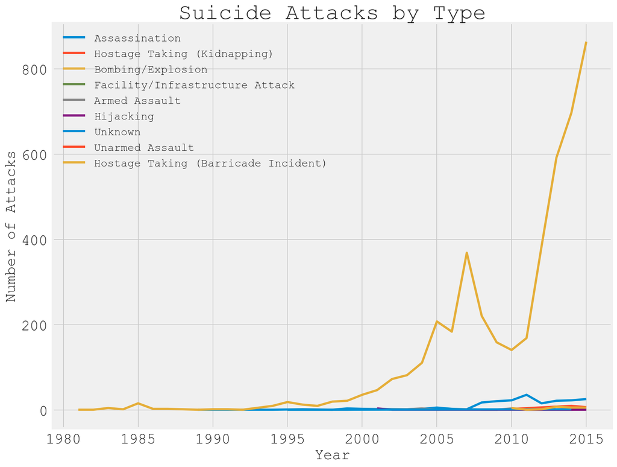

```python
attacks_by_type = df[['iyear','attacktype1_txt','attacktype1']][df.suicide==1].groupby(['iyear','attacktype1_txt']).attacktype1.count().reset_index()
attacks_by_type.rename(columns={'attacktype1_txt':'Attack Type'},inplace=True)
attacks_by_type.set_index('iyear',inplace=True)

for atype in list(df.attacktype1_txt.unique()):
    plt.plot(attacks_by_type[['attacktype1']][attacks_by_type['Attack Type']==atype],label=atype,linewidth=3.0)
    # plt.plot(attacks_by_type,hue='Attack Type')
plt.rcParams['figure.figsize'] = (10, 8)
plt.xlabel('Year',fontsize=20)
plt.ylabel('Number of Attacks',fontsize=20)
plt.title('Suicide Attacks by Type',fontsize=30)
plt.legend(prop={'size':15})
plt.show()
```

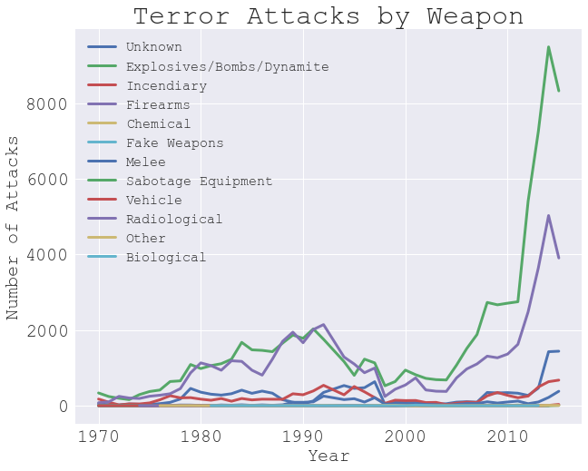

```python
df['weaptype1_txt'].replace({'Vehicle (not to include vehicle-borne explosives, i.e., car or truck bombs)':'Vehicle'},inplace=True)

attacks_by_weapon = df[['iyear','weaptype1_txt','weaptype1']].groupby(['iyear','weaptype1_txt']).weaptype1.count().reset_index()
attacks_by_weapon.rename(columns={'weaptype1_txt':'Weapon'},inplace=True)
attacks_by_weapon.set_index('iyear',inplace=True)

attacks_by_weapon

for atype in list(df.weaptype1_txt.unique()):
    plt.plot(attacks_by_weapon[['weaptype1']][attacks_by_weapon['Weapon']==atype],label=atype,linewidth=3.0)
    # plt.plot(attacks_by_type,hue='Attack Type')
plt.xlabel('Year',fontsize=20)
plt.ylabel('Number of Attacks',fontsize=20)
plt.title('Terror Attacks by Weapon',fontsize=30)
plt.legend(prop={'size':15})
plt.show()
```

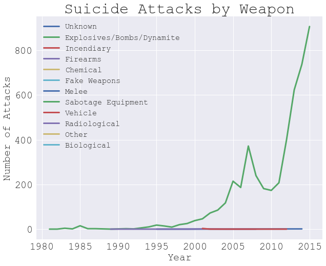

```python
df['weaptype1_txt'].replace({'Vehicle (not to include vehicle-borne explosives, i.e., car or truck bombs)':'Vehicle'},inplace=True)

attacks_by_weapon = df[['iyear','weaptype1_txt','weaptype1']][df.suicide==1].groupby(['iyear','weaptype1_txt']).weaptype1.count().reset_index()
attacks_by_weapon.rename(columns={'weaptype1_txt':'Weapon'},inplace=True)
attacks_by_weapon.set_index('iyear',inplace=True)

attacks_by_weapon

for atype in list(df.weaptype1_txt.unique()):
    plt.plot(attacks_by_weapon[['weaptype1']][attacks_by_weapon['Weapon']==atype],label=atype,linewidth=3.0)
    # plt.plot(attacks_by_type,hue='Attack Type')
plt.xlabel('Year',fontsize=20)
plt.ylabel('Number of Attacks',fontsize=20)
plt.title('Suicide Attacks by Weapon',fontsize=30)
plt.legend(prop={'size':15})
plt.show()
```

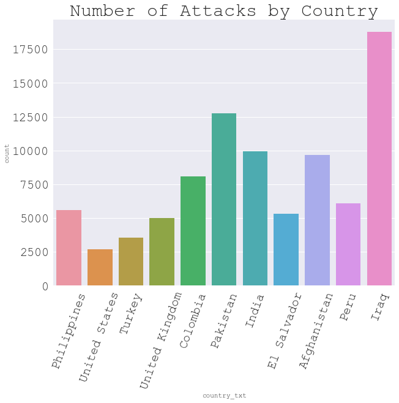

```python
import seaborn as sns
# plt.rcParams['figure.figsize'] = (16, 14)
plt.rcParams['font.size'] = 30
plt.rcParams['font.family'] = 'Courier New, monospace'
plt.rcParams['xtick.labelsize'] = 20
plt.rcParams['ytick.labelsize'] = 20
countries = df.groupby(['country_txt']).attacktype1.count().reset_index().sort_values('attacktype1',ascending=False)[0:10]
countries = list(countries.country_txt)
countries.append('United States')
mask = df[df.country_txt.isin(countries)]
sns.countplot(x="country_txt", data=mask)
plt.title('Number of Attacks by Country',size=30)
plt.xticks(rotation=70)
plt.show()
```

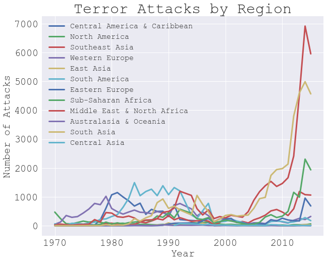

```python
attacks_by_region = df[['iyear','region_txt','region']].groupby(['iyear','region_txt']).region.count().reset_index()
attacks_by_region.rename(columns={'region_txt':'Region'},inplace=True)
attacks_by_region.set_index('iyear',inplace=True)

for atype in list(df.region_txt.unique()):
    plt.plot(attacks_by_region[['region']][attacks_by_region['Region']==atype],label=atype,linewidth=3.0)
    # plt.plot(attacks_by_type,hue='Attack Type')
plt.xlabel('Year',fontsize=20)
plt.ylabel('Number of Attacks',fontsize=20)
plt.title('Terror Attacks by Region',fontsize=30)
plt.legend(prop={'size':15})
plt.show()
```

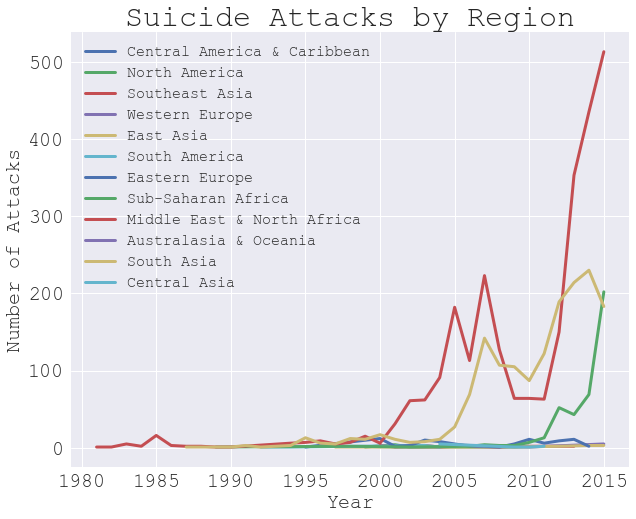

```python
attacks_by_region = df[['iyear','region_txt','region']][df.suicide==1].groupby(['iyear','region_txt']).region.count().reset_index()
attacks_by_region.rename(columns={'region_txt':'Region'},inplace=True)
attacks_by_region.set_index('iyear',inplace=True)

for atype in list(df.region_txt.unique()):
    plt.plot(attacks_by_region[['region']][attacks_by_region['Region']==atype],label=atype,linewidth=3.0)
    # plt.plot(attacks_by_type,hue='Attack Type')
plt.xlabel('Year',fontsize=20)
plt.ylabel('Number of Attacks',fontsize=20)
plt.title('Suicide Attacks by Region',fontsize=30)
plt.legend(prop={'size':15})
plt.show()
```

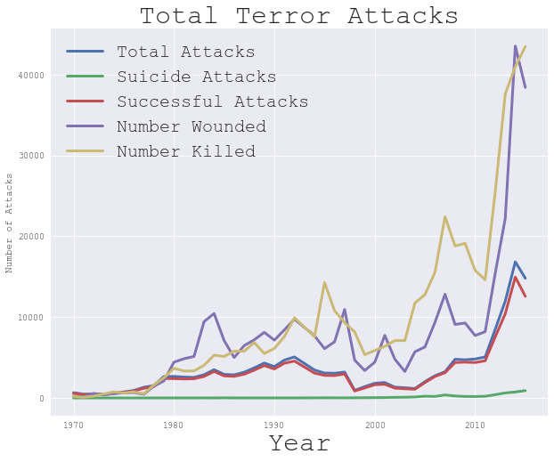

```python
from matplotlib import pyplot as plt

# get total attacks per year
attacks_by_year = df[['iyear','eventid']].groupby(['iyear']).eventid.count().reset_index()
attacks_by_year.rename(columns={'eventid':'Total Attacks'},inplace=True)

# get number of suicide attacks per year
suicide_by_year = df[['iyear','suicide']].groupby(['iyear']).suicide.sum().reset_index()
# get number of successful attacks per year
successes_by_year = df[['iyear','success']].groupby(['iyear']).success.sum().reset_index()
# get number of suicide attacks per year
nperps_by_year = df[['iyear','nperps']][df.nperps!=-99].groupby(['iyear']).nperps.sum().reset_index()
# get number killed per year
killed_by_year = df[['iyear','nkill']].groupby(['iyear']).nkill.sum().reset_index()
# get number wounded per year
wounded_by_year = df[['iyear','nwound']].groupby(['iyear']).nwound.sum().reset_index()
# get number wounded per year
propval_by_year = df[['iyear','propvalue']].groupby(['iyear']).propvalue.sum().reset_index()

# combine into one df
attacks_by_year = attacks_by_year.merge(suicide_by_year,left_on='iyear',right_on='iyear')
attacks_by_year = attacks_by_year.merge(successes_by_year,left_on='iyear',right_on='iyear')
attacks_by_year = attacks_by_year.merge(nperps_by_year,left_on='iyear',right_on='iyear')
attacks_by_year = attacks_by_year.merge(killed_by_year,left_on='iyear',right_on='iyear')
attacks_by_year = attacks_by_year.merge(wounded_by_year,left_on='iyear',right_on='iyear')
attacks_by_year = attacks_by_year.merge(propval_by_year,left_on='iyear',right_on='iyear')

attacks_by_year.rename(columns={'eventid':'Total Attacks',
                                'suicide':'Suicide Attacks',
                                'success':'Successful Attacks',
#                                 'nperps':'Number of Perpetrators',
                                'nkill':'Number Killed',
                                'nwound':'Number Wounded'},inplace=True)
attacks_by_year.set_index('iyear',inplace=True)

plt.plot(attacks_by_year['Total Attacks'], label="Total Attacks",linewidth=3.0)
plt.plot(attacks_by_year['Suicide Attacks'], label="Suicide Attacks",linewidth=3.0)
plt.plot(attacks_by_year['Successful Attacks'], label="Successful Attacks",linewidth=3.0)
# plt.plot(attacks_by_year['Number of Perpetrators'], label="Number of Perps")
plt.plot(attacks_by_year['Number Killed'], label="Number Wounded",linewidth=3.0)
plt.plot(attacks_by_year['Number Wounded'], label="Number Killed",linewidth=3.0)
# plt.plot(attacks_by_year['Total Property Value'], label="Total Property Value")

plt.xlabel('Year',fontsize=30)
plt.ylabel('Number of Attacks')
plt.title('Total Terror Attacks',fontsize=30)
plt.legend(prop={'size':20})
plt.show()
```

## AWESOME

Up until now, most of the line graphs have looked pretty similar, but check out the green **Suicide Attacks** line. It looks nearly constant. However, towards the more recent years, there's a slight trend. I want to investigate this further. Now I don't regret writing up all of this code in the last block.

# II. Bayesian Inference

### After looking at countless graphs, I've decided to look more closely into suicide attacks for my Bayesian estimation.

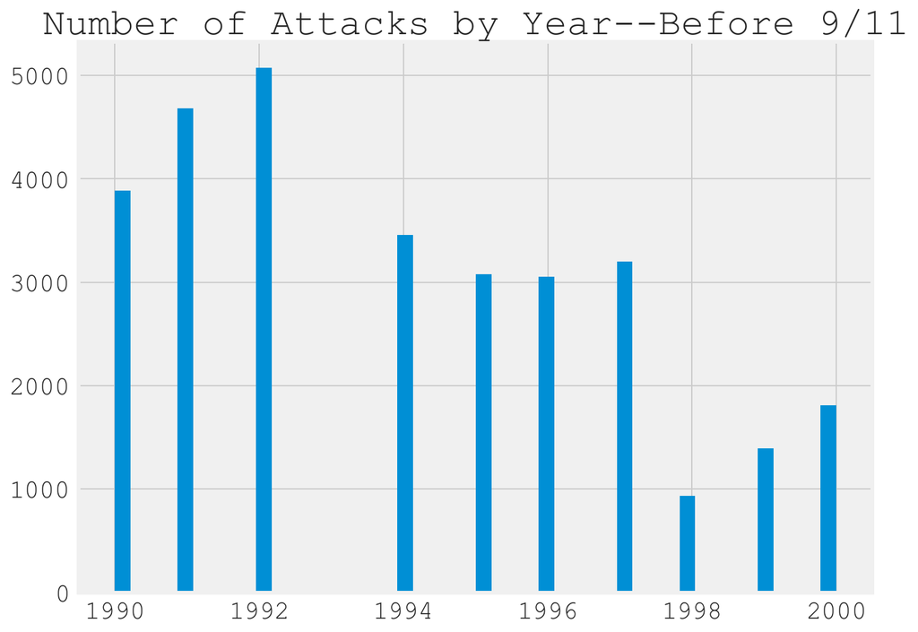

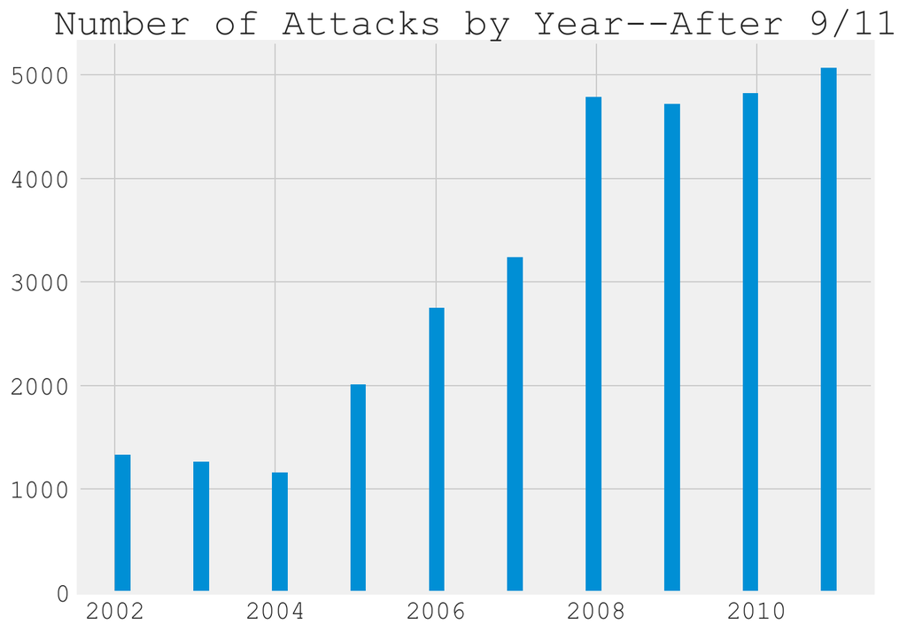

```python
# compare distributions

plt.hist(df.iyear[(df.iyear>=1990)&(df.iyear<2001)],bins=46)
plt.title('Number of Attacks by Year--Before 9/11',fontsize=30)
plt.show()
plt.hist(df.iyear[(df.iyear>2001)&(df.iyear<=2011)],bins=46)
plt.title('Number of Attacks by Year--After 9/11',fontsize=30)
```

```python
print 'Avg # suicide attacks before 9/11 =', round(df.iyear[(df.iyear>=1990)&(df.iyear<2001)].value_counts().mean(),2),'; total =', df.iyear[(df.iyear>=1990)&(df.iyear<2001)].value_counts().sum()
print 'Avg # suicide attacks after 9/11 =', round(df.iyear[(df.iyear>2001)&(df.iyear<=2011)].value_counts().mean(),2), '; total =', df.iyear[(df.iyear>2001)&(df.iyear<=2011)].value_counts().sum()
```

[output not shown]

So they're both pretty high averages, but I can't say with confidence whether or not the difference is statistically significant. Let's try to figure that out.

```python
import matplotlib.pyplot as plt
import numpy as np
import pandas as pd
import seaborn as sns
import pymc3 as pm
plt.style.use('fivethirtyeight')

%matplotlib inline
%config InlineBackend.figure_format = 'retina'
```

```
Couldn't import dot_parser, loading of dot files will not be possible.
```

#### Determine the Prior

As this was one of the deadliest attacks in hugely populated areas of the US, and was broadly publicized, I would assume that the number of suicide attacks would increase sadly due to popularization of radical extremist groups.

```python
# df with only the suicide attacks
base = df[df.suicide==1]

# df for prior
df_prior = df[df.iyear<1990].iyear.value_counts()

# df for both of the time periods I'm comparing
df_before = df[(df.iyear<2001)&(df.iyear>=1990)].iyear.value_counts()
df_after = df[(df.iyear>2001)&(df.iyear<=2011)].iyear.value_counts()
```

#### Set up Prior Distribution

```python
# set up bayesian model and priors on means
mean_prior_mean = df_prior.mean()
mean_prior_std  = df_prior.std()

print 'mean =', round(mean_prior_mean,2)
print 'std =', round(mean_prior_std,2)
```

```
mean = 2049.8
std = 1256.56
```

```python
std_prior_lower = 0.01
std_prior_upper = 100.0

# set the prior distribution to both time periods before and after 9/11
# prior belief that the number of suicide attacks is the same
with pm.Model() as model:

    before_mean = pm.Normal('before_mean', mean_prior_mean, sd=mean_prior_std)
    after_mean = pm.Normal('after_mean', mean_prior_mean, sd=mean_prior_std)

    before_std = pm.Uniform('before_std', lower=std_prior_lower, upper=std_prior_upper)
    after_std = pm.Uniform('after_std', lower=std_prior_lower, upper=std_prior_upper)
```

#### Set up Posterior Distribution

```python
# using the prior distribution, we will set up the posterior distribution
# so using before/after_means, stds, and then adding the observed suicide attacks
# in both the time periods before and after 9/11

with model:

    posterior_before = pm.Normal('Before_9_11', mu=before_mean, sd=before_std, observed=df_before)
    posterior_after = pm.Normal('After_9_11)', mu=after_mean, sd=after_std, observed=df_after)
```

#### Gather Stats on Posterior Distributions

```python
with model:

    diff_of_means = pm.Deterministic('difference of means', after_mean - before_mean)
    diff_of_stds = pm.Deterministic('difference of stds', after_std - before_std)
    effect_size = pm.Deterministic('effect size',
                                   diff_of_means / np.sqrt((after_std**2 + before_std**2) / 2))
```

```python
with model:
    trace = pm.sample(25000, njobs=4)
```

```
Auto-assigning NUTS sampler...
Initializing NUTS using advi...
Finished [100%]: Average ELBO = -3,104.3
```

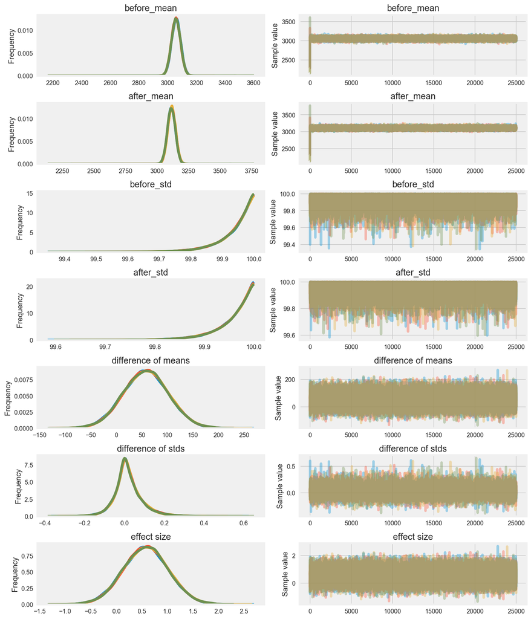

```python
pm.traceplot(trace);
# these colors are horrendous
```

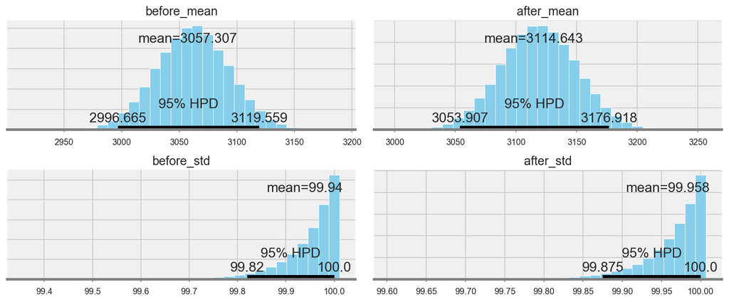

```python
pm.plot_posterior(trace[3000:],
                  varnames=['after_mean', 'before_mean', 'before_std', 'after_std'],
                  color='#87ceeb');
```

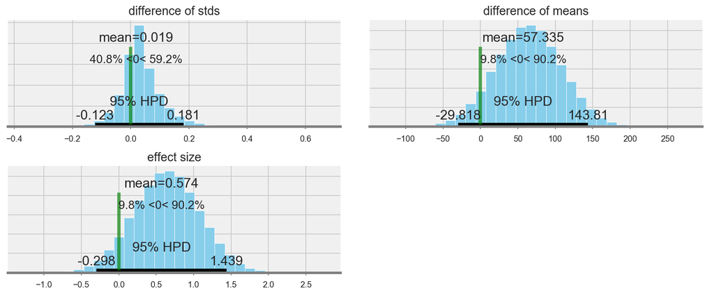

```python
pm.plot_posterior(trace[3000:],
                  varnames=['difference of means', 'difference of stds', 'effect size'],
                  ref_val=0,
                  color='#87ceeb');
```

```python
pm.summary(trace[3000:],
           varnames=['difference of means', 'difference of stds', 'effect size'])
```

```
difference of means:

  Mean             SD               MC Error         95% HPD interval
  -------------------------------------------------------------------

  57.335           44.451           0.152            [-29.818, 143.810]

  Posterior quantiles:
  2.5            25             50             75             97.5
  |--------------|==============|==============|--------------|

  -29.719        27.264         57.399         87.175         144.000


difference of stds:

  Mean             SD               MC Error         95% HPD interval
  -------------------------------------------------------------------

  0.019            0.073            0.000            [-0.123, 0.181]

  Posterior quantiles:
  2.5            25             50             75             97.5
  |--------------|==============|==============|--------------|

  -0.116         -0.020         0.010          0.052          0.190


effect size:

  Mean             SD               MC Error         95% HPD interval
  -------------------------------------------------------------------

  0.574            0.445            0.002            [-0.298, 1.439]

  Posterior quantiles:
  2.5            25             50             75             97.5
  |--------------|==============|==============|--------------|

  -0.297         0.273          0.574          0.872          1.441
```

# III. Impute 1993 Values

The codebook for the dataset describes how the poor handling of the data over time has led to the loss of some of the 1993 data. It is therefore excluded from the dataset as to not provide a false representation of the actual distribution.

The instruction was to impute the number of 1993 bombings, but I'll also do it for the other attack types.

#### Set all dates to Jan 1st of respective year -- I found that this was the only way I could get the ARMA model to work

```python
# Compile list of new dates, setting new date to the first day of the year
dates = []
for i in range(0,len(df)):
    dates.append(str(df.iyear.loc[i])+'-01-01')


# create a clean date for the actual/real date
dates_real = []
for i in range(0,len(df)):
    month = df.imonth.loc[i]
    day = df.iday.loc[i]
    if month==0:
        month = 1
    if day==0:
        day = 1
    dates_real.append(str(df.iyear.loc[i])+'-'+str(month)+'-'+str(day))


# Add Date series to df
df['Date'] = pd.Series(dates)
df.Date = pd.to_datetime(df.Date)
df['Date_real'] = pd.Series(dates_real)
df.Date_real = pd.to_datetime(df.Date_real)
```

#### Create sub-df, grouping by year to get annual counts of terror attacks

```python
impute = df[['Date','attacktype1','attacktype1_txt']][(df.attacktype1==3)&(df.iyear<=1992)].groupby(['Date','attacktype1']).attacktype1_txt.count().reset_index()
impute.rename(columns={'attacktype1_txt':'num_attacks'},inplace=True)
impute.drop(['attacktype1'],axis=1,inplace=True)

#converting 'date' column to a datetime type
impute['Date'] = pd.to_datetime(impute['Date'])
# resetting date back to the index
impute.set_index('Date',inplace = True)
```

#### Look at Data for Stationarity

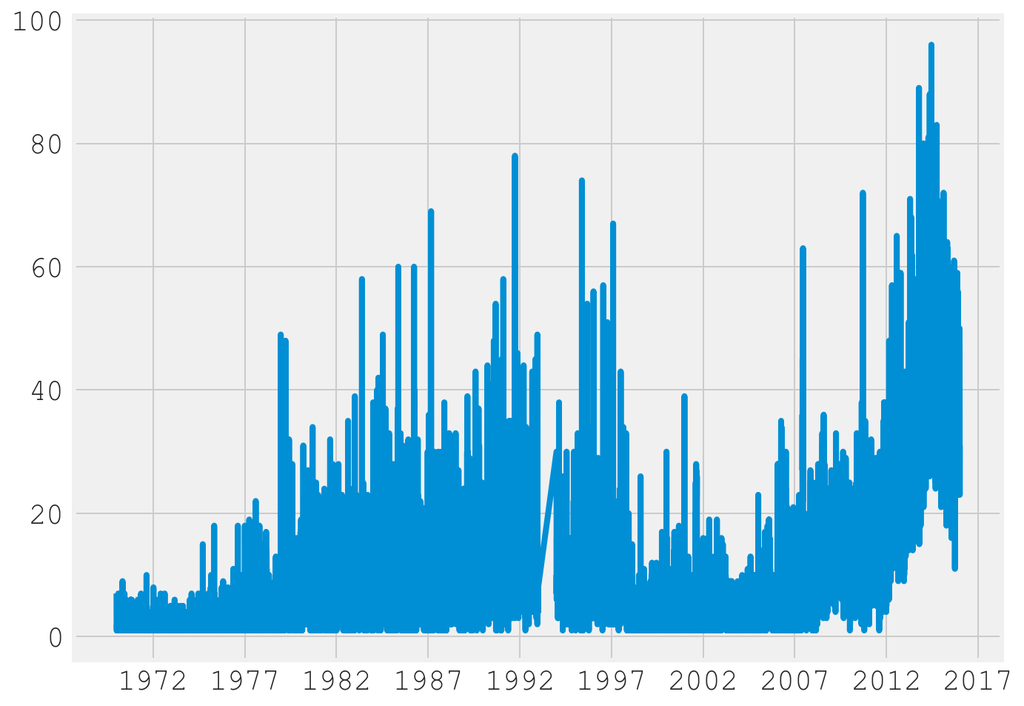

```python
import matplotlib.pyplot as plt
temp = pd.DataFrame(df[['Date_real','eventid']].groupby('Date_real').eventid.count())
temp.index = pd.to_datetime(temp.index)

plt.plot(figsize=(10,8))
plt.plot(temp)
plt.show()
```

I'm going to make a judgment call that the data is close enough to stationary that it doesn't need de-trending. It appears as though after the mean peaks around 2013-2014, it begins to fall a bit. Also, due to the sparsity of data in the earlier years, the lines are shorter than maybe they would be had all terror attacks been recorded. Conversely, it's definitely possible that before the rise of social media, less attacks were actually known. This could potentially balance out this line instead of looking like it's trending.

#### Determine p, q

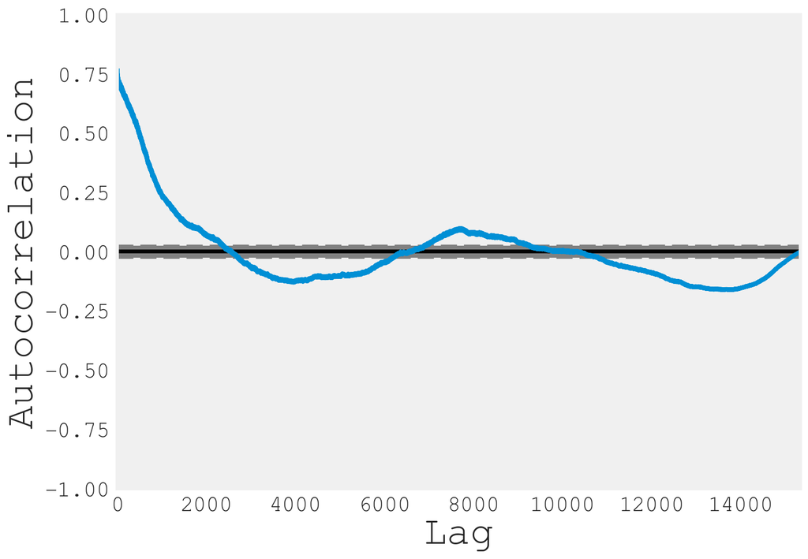

```python
from pandas.tools.plotting import autocorrelation_plot

autocorrelation_plot(temp)
plt.show()
```

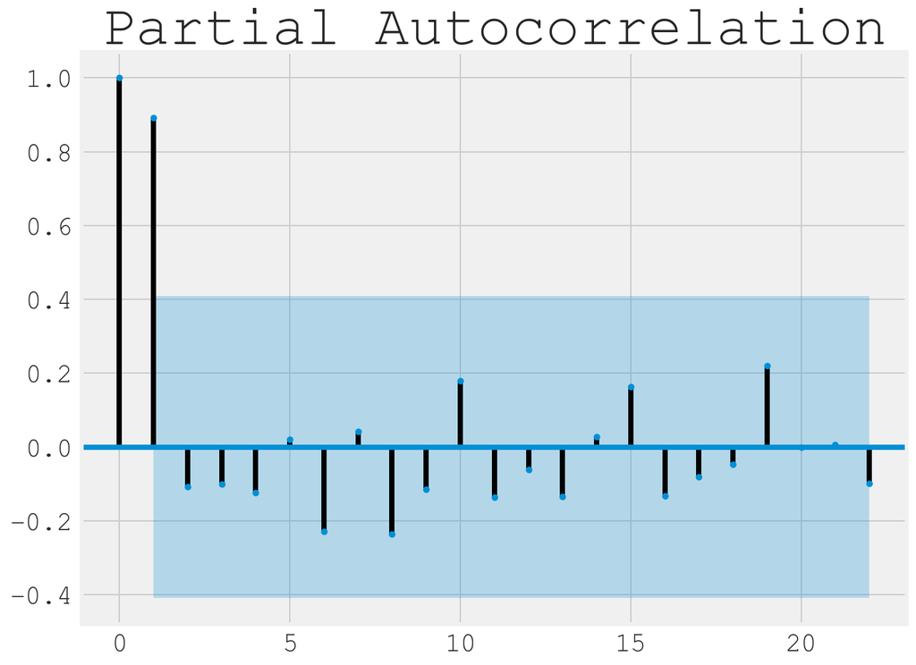

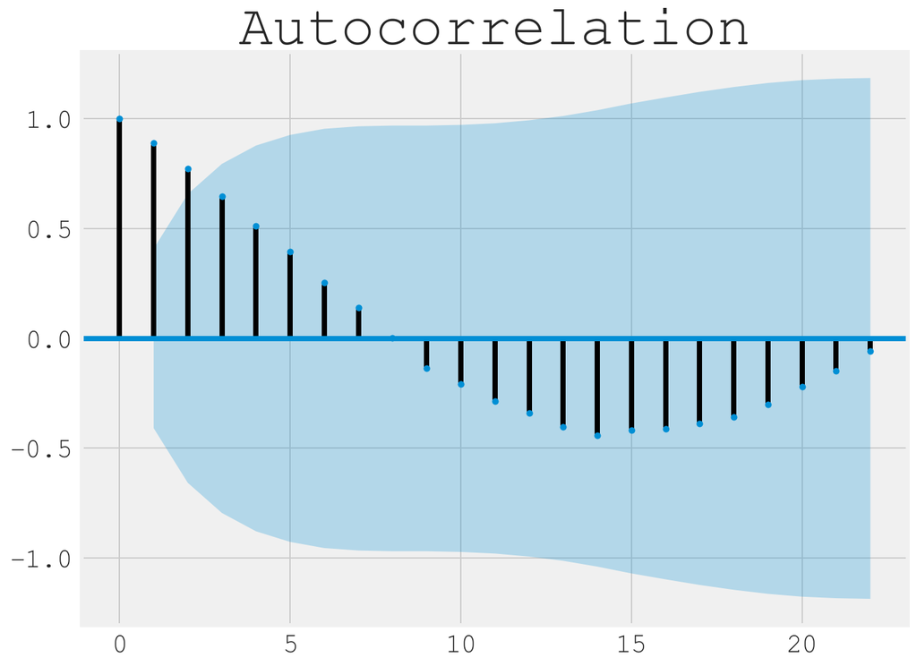

```python
from statsmodels.graphics.tsaplots import plot_acf, plot_pacf
# Look Back 20 months to analyze Autocorr and Partial Autocorr

plot_pacf(impute, lags = 22)
plt.show()

plot_acf(impute, lags = 22)
plt.show()
```

My data is grouped by year, so lags are in years. Aside from 0 in the partial autocorrelation plot, the line from 1 has the highest partial autocorr, and is the only line outside of the 95% confidence interval. This means that we will set our p=1. For the ACF plot, there is no sharp cutoff, so we will try out q=0.

#### Confirm (p,q)=(1,0) by testing out all p, q combinations to find the best fit, indicated by the lowest AIC score

```python
from __future__ import division
from statsmodels.tsa.arima_model import ARMA
# Find optimal p, q:
final_AIC = 500
p,q=0,0

for i in range(0,5):
    for j in range(0,5):
        try:
            AIC = ARMA(impute,order=(i,j)).fit().aic
            print i,j,AIC
            if AIC < final_AIC:
                final_AIC = AIC
                p, q =i,j
        except:
            pass
final_AIC, p, q


# Really glad I saved the results from the first time it ran, because I re-ran this and it doesn't do anything...

# 0 0 363.8556849
# 0 1 342.951384017
# 0 3 328.177608525
# 1 0 315.857908067
# 1 1 317.517697807
# 1 2 318.145000956
# 1 3 nan
# 1 4 331.215672293
# 2 0 317.307563434
# 2 1 316.698746446
# 2 3 nan
# 2 4 nan
# 3 0 317.73817456
# 3 2 334.171843641
# 3 3 nan
# 3 4 nan
# 4 0 319.320923525
# 4 2 nan
# 4 4 nan

# (315.85790806726385, 1, 0)

# Anyways this right here ^^ is the result
```

This test has confirmed my choice for p=1, q=0.

#### Create ARMA model, using p=1 (which is just AR(1)) to imply that the prior year has an impact on the current

```
                              ARMA Model Results
==============================================================================
Dep. Variable:            num_attacks   No. Observations:                   23
Model:                     ARMA(1, 0)   Log Likelihood                -154.929
Method:                       css-mle   S.D. of innovations            193.289
Date:                Wed, 10 May 2017   AIC                            315.858
Time:                        21:14:14   BIC                            319.264
Sample:                    01-01-1970   HQIC                           316.715
                         - 01-01-1992
=====================================================================================
                        coef    std err          z      P>|z|      [0.025      0.975]
-------------------------------------------------------------------------------------
const              1036.9474    532.176      1.949      0.065      -6.099    2079.994
ar.L1.num_attacks     0.9552      0.048     19.963      0.000       0.861       1.049
                                    Roots
=============================================================================
                 Real           Imaginary           Modulus         Frequency
-----------------------------------------------------------------------------
AR.1            1.0469           +0.0000j            1.0469            0.0000
-----------------------------------------------------------------------------
```

[figure not shown]

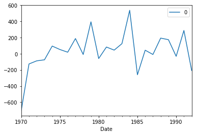

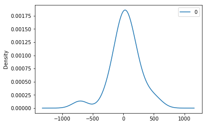

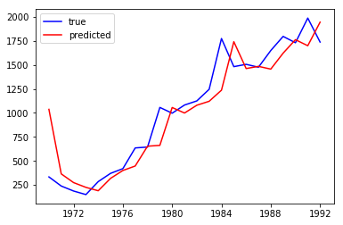

```
                0
count   23.000000
mean    29.227172
std    242.313101
min   -703.947413
25%    -67.130301
50%     43.957914
75%    149.720161
max    538.374743
```

```python
from matplotlib import pyplot as plt

# fit model
impute.num_attacks = impute.num_attacks.astype(float)
model = ARMA(impute, order=(1,0))
model_fit = model.fit()
print(model_fit.summary())

# plot residual errors
residuals = pd.DataFrame(model_fit.resid)
residuals.plot()
plt.show()
residuals.plot(kind='kde')
plt.show()
plt.plot(impute,color='blue',label='true')
plt.plot(model_fit.fittedvalues, color='red',label='predicted')
plt.legend()
plt.show()
print(residuals.describe())
```

#### Predict 1993 number of terror attacks

```python
from statsmodels.tsa.arima_model import _arma_predict_out_of_sample
# get what you need for predicting one-step ahead
params = model_fit.params
residuals = model_fit.resid
p = model_fit.k_ar
q = model_fit.k_ma
k_exog = model_fit.k_exog
k_trend = model_fit.k_trend
steps = 1

_arma_predict_out_of_sample(params, steps, residuals, p, q, k_trend, k_exog, endog=impute, exog=None, start=len(impute))
```

```
array([ 1706.56203623])
```

Here's a function to predict the number of attacks for the other attack types.

```python
from statsmodels.tsa.arima_model import _arma_predict_out_of_sample
from statsmodels.tsa.arima_model import ARMA
from matplotlib import pyplot as plt

def impute_attacks(attack_type,step=1):

    impute = df[['Date','attacktype1']][(df.attacktype1==attack_type)&(df.iyear<=1992)].groupby('Date').attacktype1.count().reset_index()
    impute.rename(columns={'attacktype1':'num_attacks'},inplace=True)
    #converting 'date' column to a datetime type
    impute['Date'] = pd.to_datetime(impute['Date'])
    # resetting date back to the index
    impute.set_index('Date',inplace = True)
    impute.num_attacks = impute.num_attacks.astype(float)
    model = ARMA(impute, order=(1,0))
    model_fit = model.fit()

    params = model_fit.params
    residuals = model_fit.resid
    p = model_fit.k_ar
    q = model_fit.k_ma
    k_exog = model_fit.k_exog
    k_trend = model_fit.k_trend
    steps = step

    attack_txt = df.attacktype1_txt[df.attacktype1==attack_type].unique()[0]
    return attack_txt, _arma_predict_out_of_sample(params, steps, residuals, p, q, k_trend, k_exog, endog=impute, exog=None, start=len(impute))[0]
```

## Results:

```python
# loop through each attack type and predict the number of attacks
predicted = []
for attack_type in (df.attacktype1.unique()):
    predicted.append(impute_attacks(attack_type))

# turn into dataframe and spit out total number of 1993 terror attacks
predicted = pd.DataFrame(predicted,columns=['Attack Type','1993 Predicted Number of Attacks'])
print 'Total # of Terror Attacks in 1993: ',predicted.sum()[1]; predicted
```

```
Total # of Terror Attacks in 1993:  4886.30141491
```

|  | Attack Type | 1993 Predicted Number of Attacks |
| --- | --- | --- |
| 0 | Assassination | 1067.181690 |
| 1 | Hostage Taking (Kidnapping) | 133.048975 |
| 2 | Bombing/Explosion | 1706.553880 |
| 3 | Facility/Infrastructure Attack | 452.218146 |
| 4 | Armed Assault | 1301.690876 |
| 5 | Hijacking | 17.084018 |
| 6 | Unknown | 143.243050 |
| 7 | Unarmed Assault | 43.069847 |
| 8 | Hostage Taking (Barricade Incident) | 22.210933 |